# Modelo para la predicción de la Edad

# 2 Modelos de regresión múltiple

## 2.1 Conjunto de test y de entrenamiento

## 2.2 Regresión múltiple

### 2.2.1 Simple

```r
lm.fit = lm(Age ~. , data=abaloneClean[train,])
summary(lm.fit)
```

```
##
## Call:
## lm(formula = Age ~ ., data = abaloneClean[train, ])
##
## Residuals:
##     Min      1Q  Median      3Q     Max
## -8.3964 -1.3053 -0.3274  0.8806 13.9703
##
## Coefficients:
##                Estimate Std. Error t value Pr(>|t|)
## (Intercept)     5.10172    0.35193  14.496  < 2e-16 ***
## SexI           -0.79229    0.12104  -6.545 6.99e-11 ***
## SexM            0.08088    0.09809   0.825   0.4097
## Length         -0.73877    2.11792  -0.349   0.7273
## Diameter        8.44337    2.62277   3.219   0.0013 **
## Height         22.91916    2.76752   8.281  < 2e-16 ***
## WholeWeight     9.65873    0.92871  10.400  < 2e-16 ***
## ShuckedWeight -20.00510    1.03760 -19.280  < 2e-16 ***
## VisceraWeight -12.01300    1.55305  -7.735 1.42e-14 ***
## ShellWeight     6.91218    1.40075   4.935 8.48e-07 ***
## ---
## Signif. codes:  0 '***' 0.001 '**' 0.01 '*' 0.05 '.' 0.1 ' ' 1
##
## Residual standard error: 2.163 on 2898 degrees of freedom
## Multiple R-squared:  0.5451, Adjusted R-squared:  0.5437
## F-statistic: 385.8 on 9 and 2898 DF,  p-value: < 2.2e-16
```

Eliminamos las variables no significativas (con grandes p-valores (>0.01)):

```r
lm.fit = lm(Age ~. -Length , data=abaloneClean[train,])
summary(lm.fit)
```

```
##
## Call:
## lm(formula = Age ~ . - Length, data = abaloneClean[train, ])
##
## Residuals:
##     Min      1Q  Median      3Q     Max
## -8.3901 -1.3037 -0.3314  0.8801 13.9934
##
## Coefficients:
##                Estimate Std. Error t value Pr(>|t|)
## (Intercept)     5.06279    0.33372  15.171  < 2e-16 ***
## SexI           -0.79444    0.12087  -6.573 5.83e-11 ***
## SexM            0.08140    0.09806   0.830    0.407
## Diameter        7.63812    1.24467   6.137 9.57e-10 ***
## Height         22.85813    2.76157   8.277  < 2e-16 ***
## WholeWeight     9.66298    0.92849  10.407  < 2e-16 ***
## ShuckedWeight -20.03503    1.03389 -19.378  < 2e-16 ***
## VisceraWeight -12.05922    1.54716  -7.794 8.95e-15 ***
## ShellWeight     6.93204    1.39938   4.954 7.70e-07 ***
## ---
## Signif. codes:  0 '***' 0.001 '**' 0.01 '*' 0.05 '.' 0.1 ' ' 1
##
## Residual standard error: 2.163 on 2899 degrees of freedom
## Multiple R-squared:  0.5451, Adjusted R-squared:  0.5438
## F-statistic: 434.2 on 8 and 2899 DF,  p-value: < 2.2e-16
```

```r
results = calculateResults(predict(lm.fit, abaloneClean), abaloneClean$Age, train, test, length(lm.fit$coefficients) - 1, "Regresion Lineal")
showResults(results)
```

| Modelo | ECM.Entrenamiento | ECM.Test | R2.adjustado.Entrenamiento | R2.adjustado.Test |
| --- | --- | --- | --- | --- |
| Regresion Lineal | 4.6619 | 4.8697 | 0.5438 | 0.5381 |

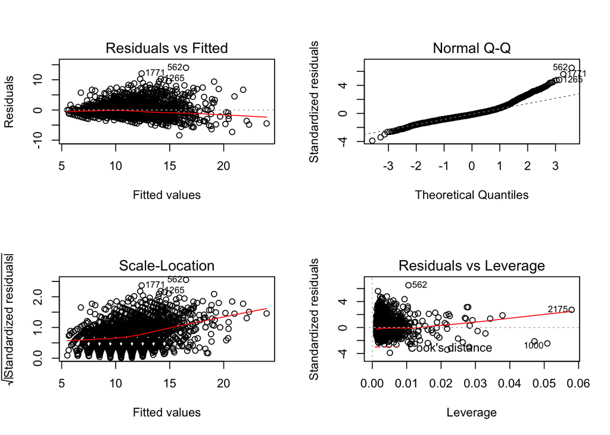

```r
par(mfrow = c(2, 2))
plot(lm.fit)
```

```r
par(mfrow = c(1, 1))
```

Observamos como los errores no son normales. Por el contrario, como ya apuntamos en el análisis exploratorio, la desviación parece aumentar con el valor de la variable dependiente y es asimétrica, con una cola más larga a la derecha. Como sospechábamos, los residuos no son homocedásticos. Veamos el resultado de transformar los pesos y de añadir variables adicionales.

### 2.2.2 Nuevas variables

```r
lm.fit = lm(Age ~ Infancy*(1 + Height + log(WholeWeight) + log(ShuckedWeight) + log(VisceraWeight) + log(ShellWeight)), data=abaloneNewFeat[train,])
summary(lm.fit)
```

```
##
## Call:
## lm(formula = Age ~ Infancy * (1 + Height + log(WholeWeight) +
##     log(ShuckedWeight) + log(VisceraWeight) + log(ShellWeight)),
##     data = abaloneNewFeat[train, ])
##
## Residuals:
##      Min       1Q   Median       3Q      Max
## -10.7003  -1.2723  -0.2894   0.8848  15.2929
##
## Coefficients:
##                             Estimate Std. Error t value Pr(>|t|)
## (Intercept)                   2.1472     1.6505   1.301 0.193386
## InfancyA                     -0.1388     2.1051  -0.066 0.947437
## Height                       34.5454     5.7324   6.026 1.89e-09 ***
## log(WholeWeight)              6.2504     1.4137   4.421 1.02e-05 ***
## log(ShuckedWeight)           -5.3579     0.7825  -6.847 9.14e-12 ***
## log(VisceraWeight)           -0.6998     0.3623  -1.932 0.053470 .
## log(ShellWeight)              0.7994     0.6289   1.271 0.203765
## InfancyA:Height             -24.1870     6.4501  -3.750 0.000180 ***
## InfancyA:log(WholeWeight)     5.5757     1.7301   3.223 0.001284 **
## InfancyA:log(ShuckedWeight)  -4.7376     0.9157  -5.174 2.45e-07 ***
## InfancyA:log(VisceraWeight)  -1.7844     0.5073  -3.517 0.000443 ***
## InfancyA:log(ShellWeight)     1.9662     0.7726   2.545 0.010986 *
## ---
## Signif. codes:  0 '***' 0.001 '**' 0.01 '*' 0.05 '.' 0.1 ' ' 1
##
## Residual standard error: 2.107 on 2896 degrees of freedom
## Multiple R-squared:  0.5687, Adjusted R-squared:  0.5671
## F-statistic: 347.2 on 11 and 2896 DF,  p-value: < 2.2e-16
```

```r
results = rbind(results, calculateResults(predict(lm.fit, abaloneNewFeat), abaloneNewFeat$Age, train, test, length(lm.fit$coefficients) - 1, "Regresion Lineal log"))


lm.fit = lm(Age ~ Infancy*(1 + Height + log(WholeWeight) + log(ShuckedWeight) + log(VisceraWeight) + log(ShellWeight) + log(WeightGeoMean) + log(WeightNorm) + Volume + SizeGeoNorm + SizeGeoMean + DensityShell + DensityShucked + Density), data=abaloneNewFeat[train,])
summary(lm.fit)
```

```
##
## Call:
## lm(formula = Age ~ Infancy * (1 + Height + log(WholeWeight) +
##     log(ShuckedWeight) + log(VisceraWeight) + log(ShellWeight) +
##     log(WeightGeoMean) + log(WeightNorm) + Volume + SizeGeoNorm +
##     SizeGeoMean + DensityShell + DensityShucked + Density), data = abaloneNewFeat[train,
##     ])
##
## Residuals:
##      Min       1Q   Median       3Q      Max
## -11.3261  -1.2360  -0.2636   0.8410  15.4226
##
## Coefficients: (2 not defined because of singularities)
##                               Estimate Std. Error t value Pr(>|t|)
## (Intercept)                   0.269932   7.126272   0.038  0.96979
## InfancyA                      7.008017  10.312391   0.680  0.49683
## Height                      -21.673651  42.281106  -0.513  0.60826
## log(WholeWeight)            -14.492700  10.633562  -1.363  0.17301
## log(ShuckedWeight)           -9.005241   2.088401  -4.312 1.67e-05 ***
## log(VisceraWeight)           -1.319295   0.497965  -2.649  0.00811 **
## log(ShellWeight)             -0.197142   1.332784  -0.148  0.88242
## log(WeightGeoMean)                  NA         NA      NA       NA
## log(WeightNorm)              27.171214  13.535179   2.007  0.04479 *
## Volume                       91.138301  40.777602   2.235  0.02549 *
## SizeGeoNorm                 -26.095737  18.842818  -1.385  0.16619
## SizeGeoMean                  50.546273  64.162658   0.788  0.43089
## DensityShell                  0.078252   0.858281   0.091  0.92736
## DensityShucked                0.058226   0.283426   0.205  0.83725
## Density                       0.002909   0.047192   0.062  0.95085
## InfancyA:Height              13.683264  50.384054   0.272  0.78597
## InfancyA:log(WholeWeight)    13.851659  14.192816   0.976  0.32916
## InfancyA:log(ShuckedWeight)  -3.539645   2.518904  -1.405  0.16006
## InfancyA:log(VisceraWeight)  -1.557649   0.693336  -2.247  0.02474 *
## InfancyA:log(ShellWeight)     1.473662   1.731100   0.851  0.39468
## InfancyA:log(WeightGeoMean)         NA         NA      NA       NA
## InfancyA:log(WeightNorm)     -8.286752  17.477939  -0.474  0.63545
## InfancyA:Volume             -47.186514  47.364935  -0.996  0.31922
## InfancyA:SizeGeoNorm         15.219839  22.269356   0.683  0.49438
## InfancyA:SizeGeoMean        -55.963647  77.420636  -0.723  0.46983
## InfancyA:DensityShell         0.320886   1.093705   0.293  0.76924
## InfancyA:DensityShucked       0.016476   0.363739   0.045  0.96387
## InfancyA:Density             -0.095820   0.084206  -1.138  0.25525
## ---
## Signif. codes:  0 '***' 0.001 '**' 0.01 '*' 0.05 '.' 0.1 ' ' 1
##
## Residual standard error: 2.1 on 2882 degrees of freedom
## Multiple R-squared:  0.5737, Adjusted R-squared:   0.57
## F-statistic: 155.1 on 25 and 2882 DF,  p-value: < 2.2e-16
```

```r
results = rbind(results, calculateResults(predict(lm.fit, abaloneNewFeat), abaloneNewFeat$Age, train, test, length(lm.fit$coefficients) - 1, "Regresion Lineal nuevas variables"))
lm.fit = lm(Age ~ Infancy*(1 + log(WholeWeight) + log(VisceraWeight) + Volume), data=abaloneNewFeat[train,])
summary(lm.fit)
```

```
##
## Call:
## lm(formula = Age ~ Infancy * (1 + log(WholeWeight) + log(VisceraWeight) +
##     Volume), data = abaloneNewFeat[train, ])
##
## Residuals:
##     Min      1Q  Median      3Q     Max
## -5.8671 -1.5951 -0.5637  0.8335 16.0653
##
## Coefficients:
##                             Estimate Std. Error t value Pr(>|t|)
## (Intercept)                   8.2681     0.8279   9.987  < 2e-16 ***
## InfancyA                     -0.2689     1.0717  -0.251 0.801907
## log(WholeWeight)              1.0137     0.4459   2.274 0.023061 *
## log(VisceraWeight)           -0.2117     0.4221  -0.502 0.616011
## Volume                       93.4509    13.0212   7.177 9.02e-13 ***
## InfancyA:log(WholeWeight)     2.1481     0.6302   3.409 0.000662 ***
## InfancyA:log(VisceraWeight)  -1.9602     0.5827  -3.364 0.000778 ***
## InfancyA:Volume             -65.7389    14.4012  -4.565 5.21e-06 ***
## ---
## Signif. codes:  0 '***' 0.001 '**' 0.01 '*' 0.05 '.' 0.1 ' ' 1
##
## Residual standard error: 2.535 on 2900 degrees of freedom
## Multiple R-squared:  0.3744, Adjusted R-squared:  0.3729
## F-statistic:   248 on 7 and 2900 DF,  p-value: < 2.2e-16
```

```r
results = rbind(results, calculateResults(predict(lm.fit, abaloneNewFeat), abaloneNewFeat$Age, train, test, length(lm.fit$coefficients) - 1, "Regresion Lineal nuevas variables reducida"))

showResults(results)
```

| Modelo | ECM.Entrenamiento | ECM.Test | R2.adjustado.Entrenamiento | R2.adjustado.Test |
| --- | --- | --- | --- | --- |
| Regresion Lineal | 4.6619 | 4.8697 | 0.5438 | 0.5381 |
| Regresion Lineal log | 4.4197 | 4.4024 | 0.5671 | 0.5814 |
| Regresion Lineal nuevas variables | 4.3688 | 4.3810 | 0.5697 | 0.5779 |
| Regresion Lineal nuevas variables reducida | 6.4105 | 6.6139 | 0.3729 | 0.3731 |

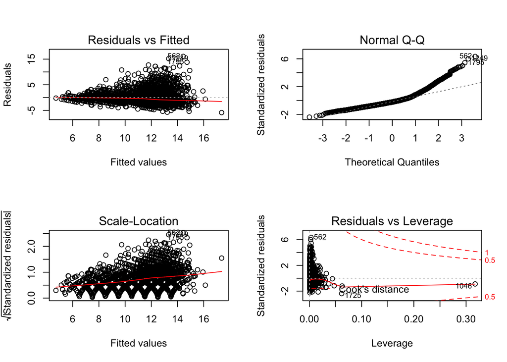

```r
par(mfrow = c(2, 2))
plot(lm.fit)
```

```r
par(mfrow = c(1, 1))
```

Probemos asignando pesos diferentes a los residuos con regresión robusta

```r
lm.fit = rlm(Age ~ Infancy*(1 + Height + log(WholeWeight) + log(ShuckedWeight) + log(VisceraWeight) + log(ShellWeight)), data=abaloneNewFeat[train,])
summary(lm.fit)
```

```
##
## Call: rlm(formula = Age ~ Infancy * (1 + Height + log(WholeWeight) +
##     log(ShuckedWeight) + log(VisceraWeight) + log(ShellWeight)),
##     data = abaloneNewFeat[train, ])
## Residuals:
##     Min      1Q  Median      3Q     Max
## -9.7478 -1.0244 -0.1015  1.0220 15.8656
##
## Coefficients:
##                             Value    Std. Error t value
## (Intercept)                   4.9301   1.3163     3.7454
## InfancyA                     -1.3264   1.6788    -0.7901
## Height                       28.4087   4.5716     6.2142
## log(WholeWeight)              4.0421   1.1274     3.5852
## log(ShuckedWeight)           -3.7954   0.6240    -6.0823
## log(VisceraWeight)           -0.3699   0.2889    -1.2804
## log(ShellWeight)              1.1441   0.5015     2.2812
## InfancyA:Height             -20.2607   5.1439    -3.9388
## InfancyA:log(WholeWeight)     6.1426   1.3797     4.4520
## InfancyA:log(ShuckedWeight)  -4.9955   0.7303    -6.8407
## InfancyA:log(VisceraWeight)  -1.7679   0.4046    -4.3697
## InfancyA:log(ShellWeight)     1.5399   0.6162     2.4992
##
## Residual standard error: 1.517 on 2896 degrees of freedom
```

```r
results = rbind(results, calculateResults(predict(lm.fit, abaloneNewFeat), abaloneNewFeat$Age, train, test, length(lm.fit$coefficients) - 1, "Regresion Robusta"))
```

## 2.3 Regresión con el método de Lasso

### 2.3.1 Generar todas las variables de interés

```r
abaloneNewFeat$LogWhole = log(abaloneNewFeat$WholeWeight)
abaloneNewFeat$LogShucked = log(abaloneNewFeat$ShuckedWeight)
abaloneNewFeat$LogViscera = log(abaloneNewFeat$VisceraWeight)
abaloneNewFeat$LogShell = log(abaloneNewFeat$ShellWeight)
```

```r
# Generación de los valores de lambda y separacion de la matrix de entradas y el vector de salida

grid = 10^seq(2,-6, length=100)
x = model.matrix(Age~.^2, abaloneNewFeat)
y = abaloneClean$Age
```

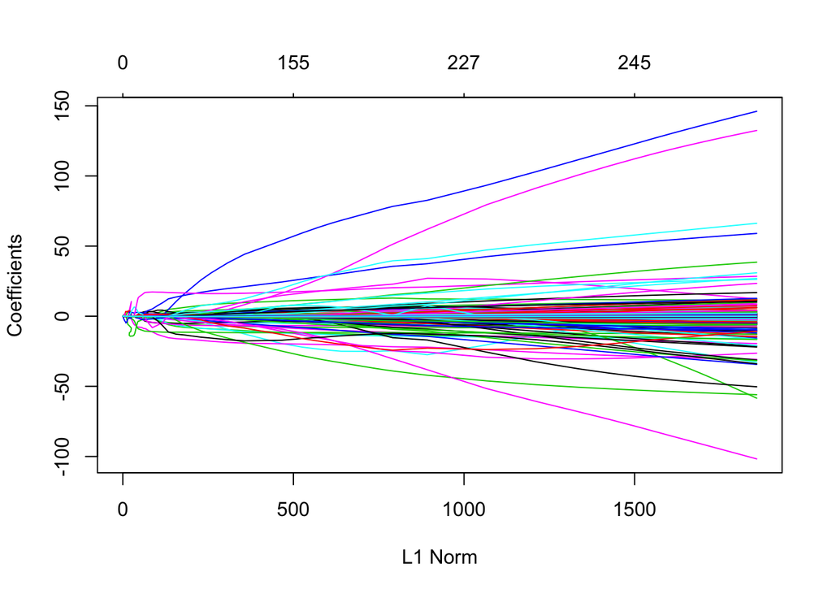

```r
# Generación del modelo de Lasso
lasso.mod = glmnet(x[train,], y[train], alpha=1, lambda=grid)
plot(lasso.mod)
```

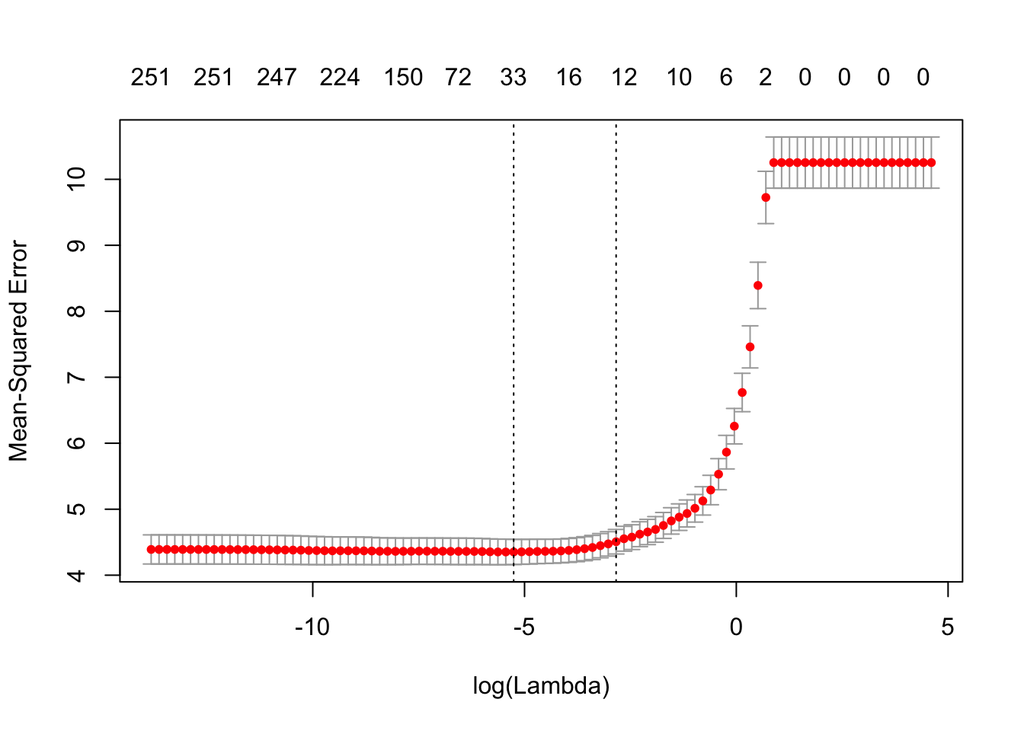

```r
# Obtención del valor de lambda que minimiza el error cuadrático medio por validación cruzada con n=10
set.seed(1)
cv.out = cv.glmnet(x[train,], y[train], alpha=1, lambda=grid, nfolds=10)
plot(cv.out)
```

```r
# Elegimos lambda que minimiza el error cuadratico medio
bestLambda = cv.out$lambda.1se
coef(lasso.mod,s=bestLambda)
```

```
## 254 x 1 sparse Matrix of class "dgCMatrix"
##                                          1
## (Intercept)                    5.170729278
## (Intercept)                    .
## SexI                           .
## SexM                           .
## Length                         .
## Diameter                       .
## Height                         .
## WholeWeight                    .
## ShuckedWeight                  .
## VisceraWeight                  .
## ShellWeight                    .
## WeightGeoMean                  .
## WeightNorm                     .
## Volume                         .
## SizeGeoMean                    .
## SizeGeoNorm                    .
## Density                        .
## DensityShucked                 .
## DensityShell                   .
## InfancyA                       .
## LogWhole                       .
## LogShucked                     .
## LogViscera                     .
## LogShell                       .
## SexI:Length                    .
## SexM:Length                    .
## SexI:Diameter                  .
## SexM:Diameter                  .
## SexI:Height                    .
## SexM:Height                    .
## SexI:WholeWeight               .
## SexM:WholeWeight               .
## SexI:ShuckedWeight             .
## SexM:ShuckedWeight             .
## SexI:VisceraWeight             .
## SexM:VisceraWeight             .
## SexI:ShellWeight               .
## SexM:ShellWeight               0.097287822
```

[output cut: 201 more lines]

```
## DensityShell:InfancyA          .
## DensityShell:LogWhole          .
## DensityShell:LogShucked        .
## DensityShell:LogViscera        .
## DensityShell:LogShell          .
## InfancyA:LogWhole              .
## InfancyA:LogShucked           -0.339438934
## InfancyA:LogViscera            .
## InfancyA:LogShell              .
## LogWhole:LogShucked            .
## LogWhole:LogViscera            .
## LogWhole:LogShell              .
## LogShucked:LogViscera          .
## LogShucked:LogShell            .
## LogViscera:LogShell            .
```

```r
# Cálculo del Error cuadrático medio del modelo en el conjunto de entrenamiento y de test
Dvar = cv.out$nzero[cv.out$lambda == bestLambda]

showResults(calculateResults(predict(lasso.mod,s=bestLambda,newx=x), y, train, test, Dvar, "Regresion Lasso"))
```

|  | Modelo | ECM.Entrenamiento | ECM.Test | R2.adjustado.Entrenamiento | R2.adjustado.Test |
| --- | --- | --- | --- | --- | --- |
| s40 | Regresion Lasso | 4.4669 | 4.5647 | 0.5624 | 0.5659 |

## 2.4 Regresión con PCA